# Pattern Analysis on Activity Monitoring Data

Jiachang (Ernest) Xu

6/20/2017

## Section 1: Loading and preprocessing the data

First of all, we load the raw data, and take a look at the top 6 rows of the raw data.

```r
## loading data from activity.csv
if(!exists("activity.raw")) {
    activity.raw <- read.csv("./data/activity.csv")
}
head(activity.raw)
```

```
##   steps       date interval
## 1    NA 2012-10-01        0
## 2    NA 2012-10-01        5
## 3    NA 2012-10-01       10
## 4    NA 2012-10-01       15
## 5    NA 2012-10-01       20
## 6    NA 2012-10-01       25
```

```r
## removing missing values
activity.valid <- activity.raw[!is.na(activity.raw$steps) & !is.na(activity.raw$date) & !is.na(activity.raw$interval), ]

## reformatting date object
activity.valid$date <- as.Date(activity.valid$date)

## converting interval into interval.index
colnames(activity.valid)[3] <- c("interval.index")
activity.valid$interval.index <- activity.valid$interval.index / 5

## glancing at activity.valid
head(activity.valid)
```

```
##     steps       date interval.index
## 289     0 2012-10-02              0
## 290     0 2012-10-02              1
## 291     0 2012-10-02              2
## 292     0 2012-10-02              3
## 293     0 2012-10-02              4
## 294     0 2012-10-02              5
```

## Section 2: What is mean total number of steps taken per day?

We use the aggregate() function to find the total number of step taken per day.

```r
## finding sum of steps per day
activity.dailysteps <- aggregate(steps ~ date, activity.valid, sum)
```

We can plot a histogarm of total number of steps per day from the aggregated data from above.

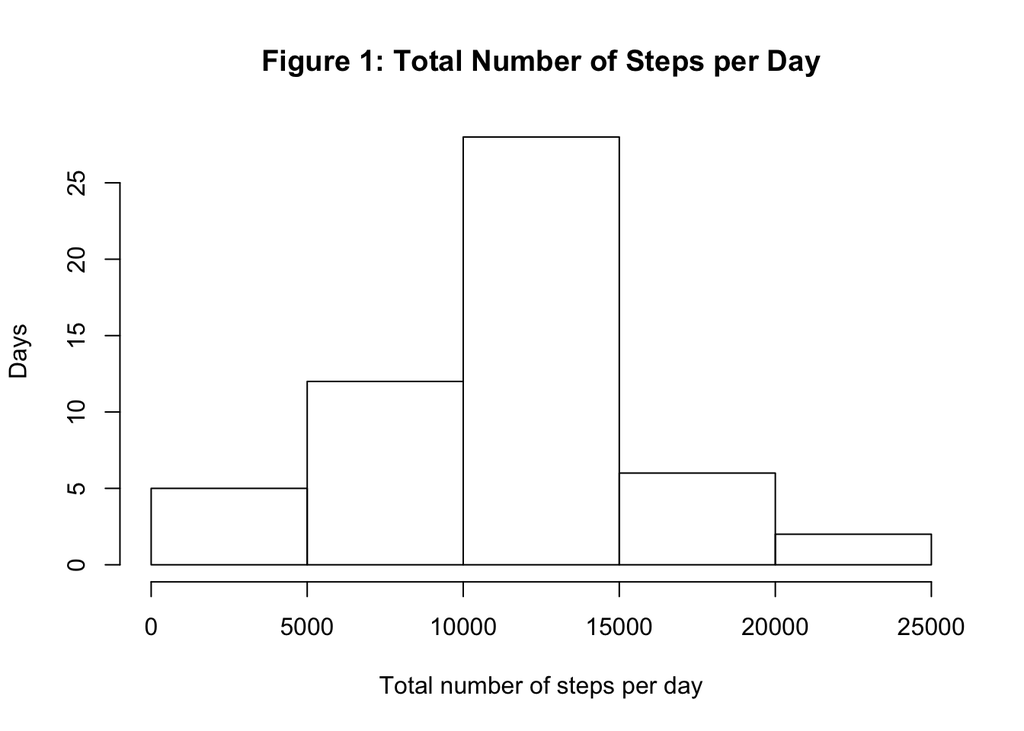

```r
## plotting histogram of the total number of steps per day
hist(activity.dailysteps$steps, xlab = "Total number of steps per day", ylab = "Days", main = "Figure 1: Total Number of Steps per Day")
```

Then, we can easily calculate the avarage from the aggregated daily activity data.

```r
mean(activity.dailysteps$steps)
```

```
## [1] 10766.19
```

## Section 3: What is the average daily activity pattern?

We use the aggregate() function to find the average number of step taken per 5-minute interval across the monitoring timeline from the valid data.

```r
## find average steps per 5-minute interval
activity.pattern <- aggregate(steps ~ interval.index, activity.valid, mean)
```

We use ggplot2 package to plot a line graph of average number of step taken per 5-minute interval from the aggregated interval activity data.

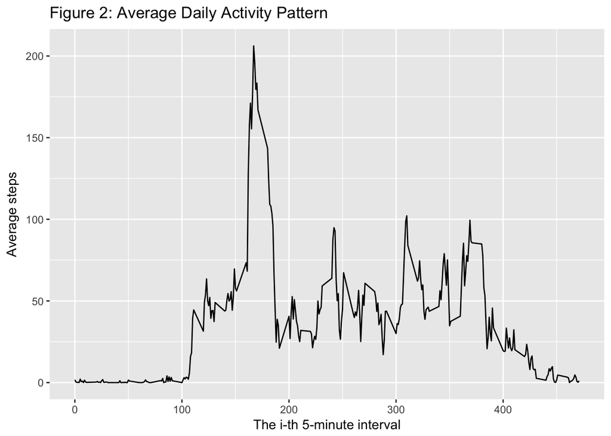

```r
## plotting daily activity pattern
require(ggplot2)
ggplot(activity.pattern, aes(interval.index, steps)) + geom_line() + xlab("The i-th 5-minute interval") + ylab("Average steps") + ggtitle("Figure 2: Average Daily Activity Pattern")
```

## Are there differences in activity patterns between weekdays and weekends?

First, we need to subset the valid data frame into weekdays and weekends data frame.

```r
## subsetting weekdays and weekends
activity.weekdays <- activity.valid[weekdays(activity.valid$date)!="Sunday" & weekdays(activity.valid$date)!="Saturday", ]
activity.weekends <- activity.valid[weekdays(activity.valid$date)=="Sunday" | weekdays(activity.valid$date)=="Saturday", ]
head(activity.weekdays)
```

```
##     steps       date interval.index
## 289     0 2012-10-02              0
## 290     0 2012-10-02              1
## 291     0 2012-10-02              2
## 292     0 2012-10-02              3
## 293     0 2012-10-02              4
## 294     0 2012-10-02              5
```

```r
head(activity.weekends)
```

```
##      steps       date interval.index
## 1441     0 2012-10-06              0
## 1442     0 2012-10-06              1
## 1443     0 2012-10-06              2
## 1444     0 2012-10-06              3
## 1445     0 2012-10-06              4
## 1446     0 2012-10-06              5
```

We use the aggregate() function to find the average number of step taken per 5-minute interval for weekdays and weekends.

```r
## aggregating by weekdays/weekends
activity.weekdays.pattern <- aggregate(steps ~ interval.index, activity.weekdays, mean)
activity.weekends.pattern <- aggregate(steps ~ interval.index, activity.weekends, mean)
```

Then, we combine two data frames into one.

```r
activity.pattern.2 <- cbind(activity.weekdays.pattern, activity.weekends.pattern$steps)
colnames(activity.pattern.2)[2:3] <- c("weekdays.steps", "weekends.steps")
head(activity.pattern.2)
```

```
##   interval.index weekdays.steps weekends.steps
## 1              0      2.3333333       0.000000
## 2              1      0.4615385       0.000000
## 3              2      0.1794872       0.000000
## 4              3      0.2051282       0.000000
## 5              4      0.1025641       0.000000
## 6              5      1.5128205       3.714286
```

Finally, we use ggplot2 package to plot two lines of average number of step taken per 5-minute interval from the aggregated interval activity data, representing weekdays and weekends patterns.

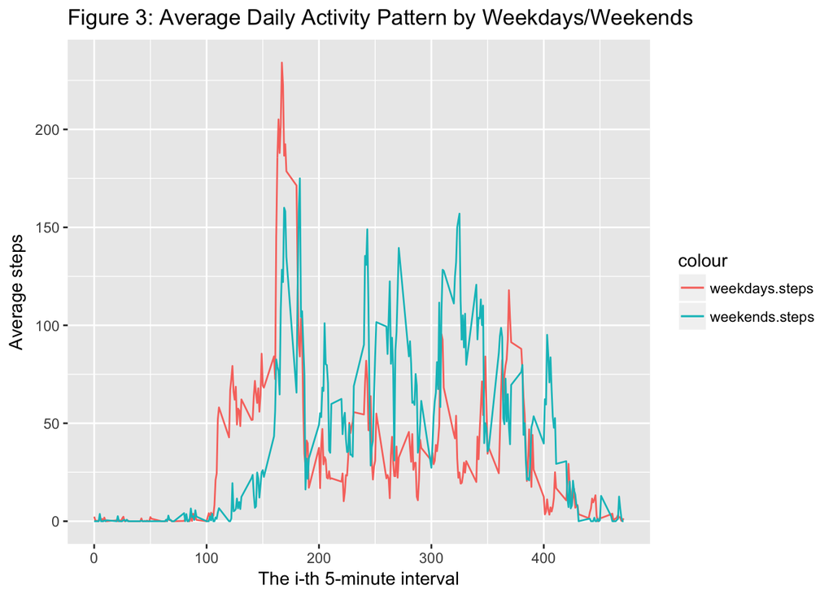

```r
## plotting average daily pattern by weekdays/weekends
require(ggplot2)
ggplot(activity.pattern.2, aes(interval.index)) +
    geom_line(aes(y = weekdays.steps, colour = "weekdays.steps")) +
    geom_line(aes(y = weekends.steps, colour = "weekends.steps")) +
    xlab("The i-th 5-minute interval") + ylab("Average steps") +
    ggtitle("Figure 3: Average Daily Activity Pattern by Weekdays/Weekends")
```